# Croissance Économique en Afrique : Le Rôle des Investissements Directs Étrangers

ROUSSEAU Nora et BOUDAMOUS Lyna

# 1 Introduction

Dans un contexte où les économies africaines cherchent à accélérer leur développement, les investissements directs étrangers (IDE) sont souvent considérés comme un levier clé pour stimuler la croissance et renforcer l’intégration dans l’économie mondiale. En tant que source de financement externe, les IDE offrent des opportunités pour l’acquisition de technologies, le transfert de savoir-faire et l’amélioration de la compétitivité des économies locales.

Cette étude vise à répondre à la question suivante :

*Quel est l’impact des investissements directs étrangers (IDE) sur le taux de croissance économique des pays africains ?*

L’objectif est de déterminer si les pays attirant davantage d’IDE enregistrent systématiquement une croissance économique plus forte par rapport à ceux qui en attirent moins. Bien que souvent perçus comme bénéfiques, les effets des IDE peuvent varier en fonction des particularités structurelles, institutionnelles et économiques des pays africains. Comprendre leur impact est crucial pour orienter les politiques économiques et ainsi maximiser les effets apportés par les IDE.

# 2 Présentation des données

Les données de panel utilisées dans cette analyse proviennent du site de la Banque mondiale de données et couvrent 32 pays africains sur la période 2000-2022. Elles permettent de capturer les variations annuelles et inter-pays de plusieurs indicateurs économiques. Les variables utilisées dans cette étude sont les suivantes :

• *Taux de croissance économique (% annuel)* : Indicateur clé mesurant la performance économique des pays africains.

• *Investissements directs étrangers (IDE) (% du PIB)* : Mesure les entrées nettes d’IDE en proportion du PIB, représentant la variable explicative principale.

• *Formation brute de capital fixe (FBCF) (% du PIB)* : Indicateur mesurant l’investissement intérieur, soit la part du PIB utilisée pour améliorer les infrastructures et les équipements.

• *Ouverture commerciale (% du PIB)* : Somme des exportations et importations en pourcentage du PIB, indiquant le degré d’intégration dans le commerce international.

• *PIB par habitant (en dollars constants de 2015)* : Mesure du niveau de vie moyen, servant de contrôle pour capturer les différences structurelles entre pays.

• *Taux de chômage (% de la population)* : Indicateur social reflétant la santé du marché du travail.

Ces données permettront d’évaluer les relations entre les IDE et la croissance économique en tenant compte des caractéristiques spécifiques à chaque pays et année, grâce à des modèles économétriques adaptés aux données de panel.

Il convient également de noter que d’autres variables, telles que la qualité des institutions, le niveau d’éducation ou la stabilité politique, auraient pu être incluses dans cette analyse mais ne le sont pas en raison de la disponibilité limitée des données.

# 3 Statistiques descriptives

| Variable | Valeurs Manquantes | Moyenne | Écart-Type | Minimum | 1er Quartile | Médiane | 3e Quartile | Maximum |
| --- | --- | --- | --- | --- | --- | --- | --- | --- |
| Taux_de_croissance | 0 | 3.80 | 6.03 | -50.34 | 2.12 | 4.25 | 6.02 | 86.83 |
| FBCF | 2 | 21.30 | 8.46 | 1.10 | 16.30 | 20.08 | 25.35 | 78.00 |
| IDE | 15 | 2.69 | 3.80 | -17.29 | 0.69 | 1.96 | 3.51 | 34.42 |
| Ouverture_commerciale | 0 | 61.76 | 25.40 | 0.00 | 44.04 | 56.91 | 77.52 | 164.28 |
| PIB_par_habitant | 0 | 2227.07 | 2293.86 | 253.69 | 699.81 | 1290.90 | 3093.16 | 13712.96 |
| Taux_de_chômage | 0 | 8.82 | 7.02 | 0.32 | 3.18 | 5.26 | 14.84 | 29.77 |

# 4 Analyse préliminaire : Relation entre IDE et taux de croissance

Nous allons estimer dans un premier temps un modèle simple afin de tester la relation entre le taux de croissance économique et les investissements directs étrangers (IDE). Le modèle peut être exprimé comme suit :

$$\text{Taux_de_croissance}_{it} = \beta_0 + \beta_1 \text{IDE}_{it} +
\varepsilon_{it}$$

```
===============================================
                        Dependent variable:
                    ---------------------------
                        Taux_de_croissance
-----------------------------------------------
IDE                          0.223***
                              (0.059)

Constant                     3.252***
                              (0.275)

-----------------------------------------------
Observations                    721
R2                             0.020
Adjusted R2                    0.018
Residual Std. Error      6.013 (df = 719)
F Statistic           14.318*** (df = 1; 719)
===============================================
Note:               *p<0.1; **p<0.05; ***p<0.01
```

**Interprétation :**

On remarque que 3,252, le coefficient de la constante est statistiquement significatif au seuil de 1%, ce qui signifie qu’en l’absence d’IDE, la croissance moyenne des pays étudiés est de 3,252 %.

Le coefficient 0,223 indique qu’une augmentation d’une unité des IDE (en pourcentage du PIB) est associée à une augmentation de 0,223 % du taux de croissance économique en moyenne, toutes choses étant égales par ailleurs. Cette relation est positive et statistiquement significative au seuil de 1 %.

La valeur de 𝑅² indique que l’effet des IDE, bien qu’existant, ne suffit pas à lui seul à expliquer le taux de croissance des pays africains. Cela suggère donc, que d’autres variables doivent être intégrés au modèle pour mieux expliquer les variations du taux de croissance.

# 5 Modèle avec toutes les variables explicatives (Modèle Poolé)

$$\text{Taux_de_croissance}_{it} = \beta_0 + \beta_1 \text{IDE}_{it} +
\beta_2 \text{FBCF}_{it} + \beta_3 \text{Ouverture_commerciale}_{it} +
\beta_4 \text{PIB_par_habitant}_{it} + \beta_5
\text{Taux_de_chômage}_{it} + \varepsilon_{it}$$

```
=================================================
                          Dependent variable:
                      ---------------------------
                          Taux_de_croissance
-------------------------------------------------
IDE                            0.216***
                                (0.064)

FBCF                             0.021
                                (0.029)

Ouverture_commerciale           0.023**
                                (0.011)

PIB_par_habitant               0.0005***
                               (0.0001)

Taux_de_chômage                -0.269***
                                (0.051)

Constant                       2.712***
                                (0.708)

-------------------------------------------------
Observations                      719
R2                               0.059
Adjusted R2                      0.052
Residual Std. Error        5.917 (df = 713)
F Statistic             8.883*** (df = 5; 713)
=================================================
Note:                 *p<0.1; **p<0.05; ***p<0.01
```

**Interprétation :**

On remarque que le modèle ne prend pas en compte d’effets spécifiques aux individus ou aux périodes, traitant toutes les variables explicatives de manière globale. Cela suggère qu’il s’agit d’un modèle poolé, où les données des différentes unités sont analysées de manière homogène, sans distinction d’effets individuels ou temporels.

On voit que les IDE (investissements directs étrangers) ont un effet positif et significatif (0,216) sur le taux de croissance économique des pays africains ce qui correspond à notre hypothèse de départ. On remarque que ce coefficient est quasiment identique à celui observé dans le modèle précédent, ce qui suggère que l’effet des IDE sur la croissance économique des pays africains reste sensiblement le même malgré les variables ajoutées.

Le coefficient de la variable FBCF (0,021) n’est pas significatif dans ce modèle, on ne peut donc pas conclure que la formation brute de capital fixe affecte le taux de croissance économique des pays africains selon ce modèle.

Le coeficient d’Ouverture commerciale est positif et significatif, ce qui soutient l’idée que l’intégration dans le commerce mondial contribue à la croissance économique. En effet, en moyenne une augmentation de 1 point de pourcentage de l’ouverture commerciale provoque une augmentation de 0,023 points du taux de croissance économique, toutes choses étant égales par ailleurs.

Le PIB par habitant est également significatif et positif, ce qui suggère que les pays avec un PIB par habitant plus élevé tendent à avoir une meilleure croissance économique même si son coefficient est faible. En effet, une augmentation de 1 dollar du PIB par habitant provoque en moyenne une hausse de 0,0005 points de pourcentage du taux de croissance économique annuel, toutes choses étant égales par ailleurs.

Le taux de chômage a un coefficient négatif et significatif, ce qui suggère qu’un taux de chômage plus élevé est associé à une croissance économique plus faible. Cela est attendu, car un chômage élevé peut réduire la productivité et la demande intérieure. Ainsi,en moyenne une augmentation de 1 point de pourcentage du taux de chômage entraîne une diminution de 0,269 points de pourcentage du taux de croissance économique annuel, toutes choses étant égales par ailleurs.

Le R² de 0,059 est faible, ce qui signifie que ce modèle explique une petite part de la variation du taux de croissance économique. Cela pourrait suggérer que d’autres facteurs non inclus dans ce modèle jouent un rôle important.

La statistique F de 8,883 est significative (p<0,01), indiquant que le modèle global est statistiquement pertinent et que les variables explicatives ont un effet collectif significatif sur la croissance économique.

Ce modèle nous donne une vue d’ensemble de la relation entre ces facteurs et le taux de croissance économique, mais il reste relativement simple et ne prend pas en compte d’effets spécifiques. Pour une analyse plus robuste, il serait pertinent d’inclure des effets fixes spécifiques aux pays, car chaque pays peut avoir un contexte structurel différent.

Afin d’évaluer la validité des hypothèses du modèle poolé nous allons réaliser un test de Breusch-Pagan.

## 5.1 Test de Breusch-Pagan

|  | Test | Statistique | p_value | Degrés_de_liberté |
| --- | --- | --- | --- | --- |
| BP | Test de Breusch-Pagan | 47.266 | 5.01351e-09 | 5 |

**Interprétation :**

Comme la p-value est inférieure à 0,05, on rejette l’hypothèse d’homoscédasticité. Cela indique la présence d’hétéroscédasticité dans ce modèle, ce qui signifie que les erreurs-types classiques risquent d’être biaisées, pouvant ainsi conduire à des estimations incorrectes des coefficients. Afin de corriger ce problème, nous allons ajuster les erreurs-types en utilisant des erreurs-types robustes, ce qui permet de tenir compte de l’hétéroscédasticité et d’obtenir des résultats plus fiables.

## 5.2 Correction des erreurs types

```
t test of coefficients:

                         Estimate  Std. Error t value  Pr(>|t|)
(Intercept)            2.71151386  0.87258510  3.1074 0.0019620 **
IDE                    0.21567383  0.06778192  3.1819 0.0015267 **
FBCF                   0.02146014  0.04622982  0.4642 0.6426421
Ouverture_commerciale  0.02336829  0.01490267  1.5681 0.1173106
PIB_par_habitant       0.00045729  0.00019053  2.4001 0.0166449 *
Taux_de_chômage       -0.26892003  0.07875542 -3.4146 0.0006749 ***
---
Signif. codes:  0 '***' 0.001 '**' 0.01 '*' 0.05 '.' 0.1 ' ' 1
```

**Interprétation :**

Après avoir ajusté les erreurs-types pour prendre en compte l’hétéroscédasticité, on voit que les IDE, le PIB par habitant et le taux de chômage influencent de manière significative la croissance, tandis que la formation brute de capital fixe et l’ouverture commerciale n’ont pas d’effet statistiquement significatif dans ce modèle. Ces ajustements permettent d’obtenir des résultats plus robustes, et fournissent une estimation plus fiable de l’impact des différentes variables sur la croissance économique.

# 6 Comparaison des Modèles Poolés avec et sans effets fixes par pays

Le modèle poolé avec effets fixes par pays s’écrit comme suit :
$$\text{Taux_de_croissance}_{it} = \beta_0 + \beta_1 \text{IDE}_{it} +
\beta_2 \text{FBCF}_{it} + \beta_3 \text{Ouverture_commerciale}_{it} +
\beta_4 \text{PIB_par_habitant}_{it} + \beta_5
\text{Taux_de_chômage}_{it} + \gamma_i \text{Pays}_i + \varepsilon_{it}$$

```
===================================================================
                                       Dependent variable:
                              -------------------------------------
                                       Taux_de_croissance
                              Poolé sans EF pays Poolé avec EF pays
                                     (1)                (2)
-------------------------------------------------------------------
IDE                                0.216***           0.178**
                                   (0.064)            (0.069)

FBCF                                0.021              -0.066
                                   (0.029)            (0.042)

Ouverture_commerciale              0.023**            0.062***
                                   (0.011)            (0.017)

PIB_par_habitant                  0.0005***           0.003***
                                   (0.0001)           (0.0004)

Taux_de_chômage                   -0.269***            -0.038
                                   (0.051)            (0.130)

factor(Pays)Algérie                                   6.036***
                                                      (2.171)

factor(Pays)Angola                                   11.062***
                                                      (2.455)

factor(Pays)Bénin                                    18.210***
                                                      (3.904)

factor(Pays)Botswana                                   -2.004
                                                      (1.874)

factor(Pays)Burkina Faso                             20.329***
                                                      (3.767)

factor(Pays)Burundi                                  19.143***
                                                      (4.063)

```

[output cut: 69 more lines]

```
factor(Pays)Tunisie                                   4.573**
                                                      (2.302)

factor(Pays)Zimbabwe                                 11.773***
                                                      (3.461)

Constant                           2.712***          -18.805***
                                   (0.708)            (4.179)

-------------------------------------------------------------------
Observations                         719                719
R2                                  0.059              0.163
Adjusted R2                         0.052              0.119
===================================================================
Note:                                   *p<0.1; **p<0.05; ***p<0.01
```

**Interprétation :**

Avant, le coefficient de l’intercept était 2,712, tandis qu’après l’ajout des effets fixes pays, il devient -18,805, ce qui montre le changement important qu’a provoqué l’ajout des spécificités propres à chaque pays.

Le coefficient des IDE dans le modèle avec effets fixes pays est 0,178, tandis que dans le modèle sans effets fixes, il est 0,216. L’effet reste positif dans les deux cas, mais il est plus faible dans le modèle avec effets fixes, ce qui peut indiquer que les spécificités des pays (capturées par les effets fixes) modèrent l’impact des IDE sur la croissance économique.

Dans les deux modèles, FBCF n’a pas d’effet significatif, mais son coefficient est très différent ; il est négatif dans le modèle avec effets fixes et légèrement positif dans le modèle sans. Ce changement de signe peut indiquer que la formation brute en capital fixe a des impacts différents selon les contextes nationaux.

Le PIB par habitant a un impact positif mais faible dans les deux modèles. Toutefois, le coefficient est beaucoup plus grand dans le modèle avec effets fixes (0,003 contre 0,0005), ce qui pourrait suggérer que le modèle avec effets fixes reflète mieux la relation entre le développement économique (représenté par le PIB par habitant) et la croissance.

Le coefficient pour le taux de chômage est significatif dans le modèle sans effets fixes, mais il ne l’est pas dans le modèle avec effets fixes. On en déduit donc que les spécificités nationales influencent la relation entre le chômage et la croissance économique.

On remarque que l’Afrique du Sud n’apparaît pas dans les résultats du modèle avec effets fixes par pays, ce qui signifie qu’elle a été utilisée comme pays de référence. En effet, dans un modèle avec effets fixes, le pays de référence est exclu afin d’éviter la multicolinéarité. Ainsi, les coefficients des autres pays représentent l’écart de leur taux de croissance par rapport à celui de l’Afrique du Sud. Cela permet de mettre en évidence les spécificités nationales et de comprendre comment chaque pays se distingue de l’Afrique du Sud en termes de croissance économique, tout en tenant compte des effets fixes propres à chaque pays.

Angola : Le taux de croissance économique de l’Angola est supérieur de 11,062 points à celui de l’Afrique du Sud. L’Angola a connu une forte croissance dans les années récentes grâce à ses ressources pétrolières et à des réformes économiques, ce qui pourrait expliquer cette différence importante par rapport à l’Afrique du Sud.

Bénin : Le taux de croissance économique du Bénin est supérieur de 18,210 points à celui de l’Afrique du Sud. Bien que le Bénin soit un petit pays, sa politique de réformes économiques et sa diversification des exportations ont contribué à un taux de croissance relativement élevé ces dernières années.

Libye : Le coefficient de la Libye est de -16,958 ce qui signifie que le taux de croissance économique de la Libye est significativement plus bas que celui de l’Afrique du Sud, de 16,958 points en moyenne. Cette différence pourrait être due à des facteurs structurels et économiques spécifiques à la Libye, comme les crises politiques, les sanctions économiques, ou d’autres défis internes.

Le R² ajusté est plus élevé dans le modèle avec effets fixes spécifiques à chaque pays (0,119 contre 0,052), on en conclut donc que ce modèle explique mieux la variabilité du taux de croissance économique que le modèle poolé sans effets fixes par pays.

Après avoir comparé les modèles avec et sans effets fixes, il est essentiel de vérifier la qualité de l’ajustement du modèle avec effets fixes par pays. Nous allons donc visualiser les résidus pour vérifier l’homoscédasticité et l’indépendance des erreurs, et effectuer le test de Durbin-Watson pour détecter une éventuelle autocorrélation des résidus.

## 6.1 Visualisation des résidus

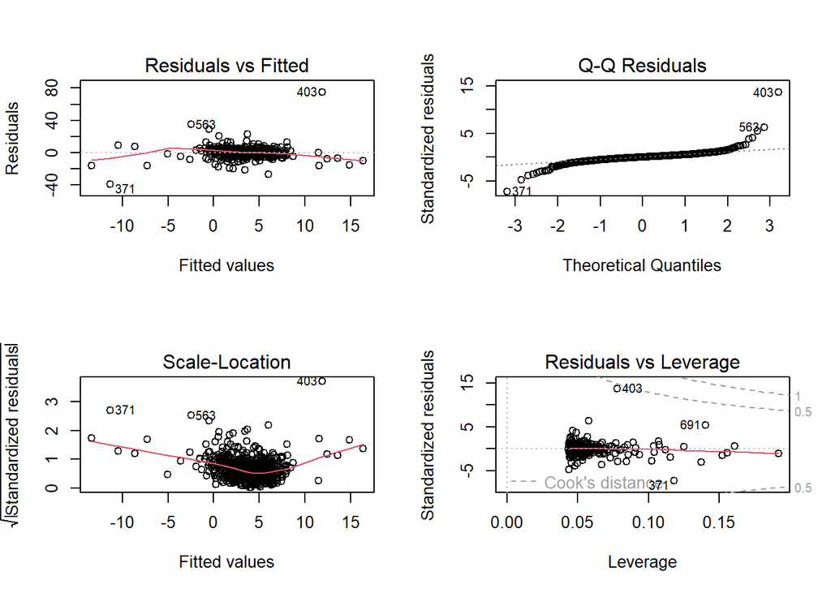

**Interprétation :**

Les résultats montrent des signes d’hétéroscédasticité, notamment à travers le graphique “Residuals vs Fitted”, où l’on observe une tendance non constante de la dispersion des résidus. De plus, le graphique Q-Q suggère une non-normalité des résidus, avec des écarts importants par rapport à la droite. Enfin, le graphique “Residuals vs Leverage” met en évidence la présence de points influents, qui pourraient affecter la robustesse des estimations du modèle et nécessitent donc une attention particulière.

## 6.2 Test de l’autocorrélation des résidus (Durbin-Watson)

|  | Test | Statistique | p_value |
| --- | --- | --- | --- |
| DW | Test de Durbin-Watson | 1.975 | 0.3658371 |

**Interprétation :**

Puisque la p-value est supérieure à 0,05, nous ne rejetons pas l’hypothèse nulle. Cela suggère qu’il n’y a pas d’autocorrélation significative dans les résidus de notre modèle. En d’autres termes, les erreurs sont indépendantes les unes des autres, ce qui est un bon signe pour la validité des tests statistiques de notre modèle et renforce la crédibilité de nos résultats.

# 7 Modèle à Effets Fixes (Within)

```
=================================================
                          Dependent variable:
                      ---------------------------
                          Taux_de_croissance
-------------------------------------------------
IDE                             0.178**
                                (0.069)

FBCF                            -0.066
                                (0.042)

Ouverture_commerciale          0.062***
                                (0.017)

PIB_par_habitant               0.003***
                               (0.0004)

Taux_de_chômage                 -0.038
                                (0.130)

-------------------------------------------------
Observations                      719
R2                               0.124
Adjusted R2                      0.078
F Statistic             19.287*** (df = 5; 682)
=================================================
Note:                 *p<0.1; **p<0.05; ***p<0.01
```

Le modèle within est un modèle qui se concentre spécifiquement sur les variations au sein de chaque pays (et non entre les pays). En d’autres termes, ce modèle élimine les effets constants entre les pays pour se concentrer sur l’impact des variables explicatives sur la croissance économique, en prenant en compte les changements dans chaque pays au fil du temps.

**Interprétation :**

On voit que les IDE ont un effet positif sur le taux de croissance. Une augmentation de 1% des IDE (en % du PIB) est associée à une augmentation de 0,178% du taux de croissance économique des pays africains, en moyenne, toutes choses égales par ailleurs.

Le coefficient 0,062 suggère qu’en moyenne, une augmentation de 1% de l’ouverture commerciale est associée à une augmentation de 0,062% du taux de croissance économique des pays africains. Cette relation est hautement significative, ce qui montre une relation forte entre cette variable et la croissance économique des pays africains.

En moyenne, une augmentation de 1 dollar du PIB par habitant (en dollars constants de 2015) est associée à une augmentation de 0,003% du taux de croissance économique. Bien que l’impact soit positif, il reste faible, mais est hautement significatif, ce qui signifie que le niveau de vie moyen a un impact important, même si son effet est modeste.

L’impact du chômage et de la formation brute de capital fixe (FBCF) sur la croissance économique n’est pas statistiquement significatif dans ce modèle, ce qui empêche de conclure à une relation fiable entre ces variables et la croissance économique des pays africains.

On remarque que le R² est relativement faible, indiquant que le modèle explique seulement une petite fraction de la variation du taux de croissance, mais le modèle dans son ensemble est significatif, comme le montre la F-statistic.

# 8 Modèle à effets aléatoires

```
=================================================
                          Dependent variable:
                      ---------------------------
                          Taux_de_croissance
-------------------------------------------------
IDE                            0.216***
                                (0.064)

FBCF                             0.021
                                (0.029)

Ouverture_commerciale           0.023**
                                (0.011)

PIB_par_habitant               0.0005***
                               (0.0001)

Taux_de_chômage                -0.269***
                                (0.051)

Constant                       2.712***
                                (0.708)

-------------------------------------------------
Observations                      719
R2                               0.059
Adjusted R2                      0.052
F Statistic                    44.415***
=================================================
Note:                 *p<0.1; **p<0.05; ***p<0.01
```

Le modèle à effets aléatoires permet de capturer les variations spécifiques à chaque pays tout en supposant que ces effets sont indépendants des variables explicatives. Contrairement aux effets fixes, il conserve les différences entre les pays, ce qui le rend plus flexible. Cependant, il repose sur l’hypothèse que les effets non observés ne sont pas corrélés avec les variables explicatives du modèle.

**Interprétation :**

Le modèle à effets aléatoires montre que l’IDE, l’Ouverture commerciale, le PIB par habitant, et le Taux de chômage ont des effets significatifs sur le taux de croissance.

La FBCF n’a pas d’impact significatif dans ce modèle.

Le R² est relativement faible, indiquant que le modèle n’explique qu’une petite fraction de la variation du taux de croissance.

Malgré ce faible R², le modèle est globalement significatif, comme l’indique la F-statistic.

# 9 Test de Hausman

Afin de déterminer quel modèle retenir, nous allons effectuer un test d’Hausman qui nous permettra de savoir quel modèle est le mieux adapté à nos données entre un modèle à effets aléatoires et un modèle à effets fixes.

- H0 : E(ui/ Xi) = 0, les effets individuels ne sont pas corrélés aux variables explicatives
- H1 : E(ui/ Xi) ≠ 0, les effets individuels sont corrélés aux variables explicatives

| Test | chisq | df | p_value | Conclusion |
| --- | --- | --- | --- | --- |
| Test de Hausman | chisq = 67.237 | df = 5 | 3.847634e-13 | Les effets fixes sont préférables aux effets aléatoires |

**Interprétation :**

La p-value étant inférieure à 0,05, cela signifie que l’hypothèse nulle est rejetée, indiquant que les effets individuels sont corrélés avec les variables explicatives. Par conséquent, cela suggère que le modèle à effets fixes est le plus adapté, car il permet de prendre en compte cette corrélation.

# 10 Test de Fisher

Ce test nous aide à choisir entre un modèle dit poolé ou un modèle à effets fixes.

- H0 : Si tous les Ci = 0, alors il n’y a pas d’effets de panel, il n’y a pas d’hétérogénéité individuelle dans nos données ;
- H1 : Si au moins un Ci ≠ 0, alors il y a des effets de panel à prendre en compte, il y a de l’hétérogénéité individuelle dans nos données.

|  | F_stat | df | p_value | Conclusion |
| --- | --- | --- | --- | --- |
| F | F = 2.738 | df1 = 31, df2 = 682 | 1.910856e-06 | Les effets fixes sont appropriés |

**Interprétation :**

Étant donné que la p-value est bien inférieure à 0,05, nous rejetons l’hypothèse nulle et concluons que les effets individuels sont statistiquement significatifs. Cela indique que l’hétérogénéité individuelle doit être prise en compte dans notre modèle, et donc que le modèle à effets fixes est le plus approprié à nos données.

# 11 Comparaison des 4 modèles étudiés

```
====================================================================================
                                               Dependent variable:
                              ------------------------------------------------------
                                                Taux_de_croissance
                                        OLS                       panel
                                                                  linear
                                Poolé   Poolé EF pays Effets Fixes Effets Aléatoires
                                 (1)         (2)          (3)             (4)
------------------------------------------------------------------------------------
IDE                           0.216***     0.178**      0.178**        0.216***
                               (0.064)     (0.069)      (0.069)         (0.064)

FBCF                            0.021      -0.066        -0.066          0.021
                               (0.029)     (0.042)      (0.042)         (0.029)

Ouverture_commerciale          0.023**    0.062***      0.062***        0.023**
                               (0.011)     (0.017)      (0.017)         (0.011)

PIB_par_habitant              0.0005***   0.003***      0.003***       0.0005***
                              (0.0001)    (0.0004)      (0.0004)       (0.0001)

Taux_de_chômage               -0.269***    -0.038        -0.038        -0.269***
                               (0.051)     (0.130)      (0.130)         (0.051)

factor(Pays)Algérie                       6.036***
                                           (2.171)

factor(Pays)Angola                        11.062***
                                           (2.455)

factor(Pays)Bénin                         18.210***
                                           (3.904)

factor(Pays)Botswana                       -2.004
                                           (1.874)

factor(Pays)Burkina Faso                  20.329***
                                           (3.767)

factor(Pays)Burundi                       19.143***
```

[output cut: 71 more lines]

```
factor(Pays)Tunisie                        4.573**
                                           (2.302)

factor(Pays)Zimbabwe                      11.773***
                                           (3.461)

Constant                      2.712***   -18.805***                    2.712***
                               (0.708)     (4.179)                      (0.708)

------------------------------------------------------------------------------------
Observations                     719         719          719             719
R2                              0.059       0.163        0.124           0.059
Adjusted R2                     0.052       0.119        0.078           0.052
====================================================================================
Note:                                                    *p<0.1; **p<0.05; ***p<0.01
```

*Modèle Poolé :*

Ce modèle suppose qu’il n’y a pas de différences spécifiques entre les pays. Les coefficients montrent des résultats significatifs pour les variables étudiées sauf FBCF. Toutefois, ce modèle ne prend pas en compte l’hétérogénéité individuelle, ce qui limite sa fiabilité dans ce contexte.

*Modèle Poolé avec effets fixes par pays :*

En ajoutant des effets fixes par pays via factor(Pays), ce modèle permet de capturer l’hétérogénéité entre les pays. Les coefficients des variables explicatives restent proches de ceux du modèle à effets fixes, ce qui suggère une robustesse dans les résultats, mais les variables de contrôle par pays montrent des différences significatives entre les pays. Le coefficient constant négatif (-18,805) montre qu’une fois les particularités des pays prises en compte, cela entraîne un ajustement notable dans l’interprétation globale du modèle.

*Modèle à Effets Fixes (Within) :*

Ce modèle est préféré, comme le suggèrent les tests de Hausman et de Fisher, car il prend en compte les variations au sein des pays.

Les coefficients pour l’IDE (0,178), l’Ouverture commerciale (0,062), et le PIB par habitant (0,003) sont significatifs et montrent des effets positifs sur la croissance économique. La Formation brute de capital fixe (FBCF) et le Taux de chômage ne sont pas significatifs, indiquant une absence de preuve robuste d’effet direct sur la croissance.

*Modèle à Effets Aléatoires :*

Bien que les coefficients soient similaires à ceux du modèle poolé, les tests ont rejeté ce modèle au profit du modèle à effets fixes. Cela signifie que les effets spécifiques des pays sont corrélés avec les variables explicatives, ce qui invalide l’hypothèse sous-jacente du modèle à effets aléatoires.

**Conclusion :**

Le R² du modèle poolé avec effets fixes par pays est le plus élevé (0,163), ce qui signifie qu’il explique le mieux la variance totale de la croissance, mais cela pourrait être dû à l’ajout de nombreuses variables de contrôle spécifiques aux pays.

Le R² ajusté du modèle à effets fixes (Within) est plus modéré (0,078), indiquant qu’il explique bien la variance après avoir pris en compte les spécificités intra-pays, et qu’il évite une sur-spécification.

On choisi donc le modèle à effets Fixes (Within) car il prend en compte l’hétérogénéité individuelle des pays et capture mieux les effets des variables explicatives sur la croissance.

Le modèle poolé avec effets fixes par pays est une approche intermédiaire qui intègre les effets fixes par pays, mais il ne remplace pas complètement l’analyse détaillée des variations intra-pays, comme le fait le modèle à effets fixes.

# 12 Conclusion

Cette étude visait à évaluer l’impact des investissements directs étrangers (IDE) sur le taux de croissance économique des pays africains en utilisant des données de panel couvrant la période 2000-2022 pour 32 pays africains. Les résultats des modèles économétriques ont mis en évidence l’importance des IDE en tant que facteur influençant positivement la croissance économique dans ces pays. Bien que les coefficients des IDE soient significatifs dans tous les modèles étudiés, leur impact direct sur la croissance économique demeure modéré, ce qui suggère qu’ils contribuent à la croissance, mais dans une mesure limitée.

Le modèle à effets fixes (Within) semble être le plus adapté pour expliquer la croissance économique, en tenant compte des spécificités intra-pays. Ce modèle a montré que les IDE ont un impact positif sur la croissance, corroboré par d’autres variables telles que le PIB par habitant et l’ouverture commerciale. En revanche, des variables comme la formation brute de capital fixe (FBCF) et le taux de chômage n’ont pas montré de résultats significatifs, indiquant que ces facteurs ne jouent pas un rôle direct dans la croissance économique dans le contexte africain.

Les résultats suggèrent que les pays africains attirant davantage d’IDE tendent à enregistrer une croissance économique plus forte. Toutefois, ces effets varient selon les contextes institutionnels et structurels des pays, ce qui souligne l’importance de mettre en place des politiques adaptées pour maximiser les avantages des IDE. Cependant, il est essentiel de noter que d’autres facteurs, comme la qualité des institutions, l’investissement en infrastructures, ou la stabilité politique, pourraient avoir un rôle tout aussi important, voire plus déterminant dans certains contextes.

En conclusion, bien que les IDE aient un impact positif sur la croissance économique en Afrique, leur effet reste modéré. Pour maximiser les retombées positives des IDE, il est crucial que les pays africains améliorent leurs infrastructures, renforcent leurs institutions et favorisent une meilleure intégration dans l’économie mondiale. Une approche stratégique et ciblée des politiques économiques est donc nécessaire pour maximiser les bénéfices à long terme des IDE.